# Homework #2 Key

Aesthetic Mappings and Facets

Due: 13 Jan 2020

## Concepts

Explain how aesthetics, scaling, and mapping are related to each other within the context of the grammar of graphcs and ggplot.

Aesthetics, scaling, and mapping are referring to the same concept. This is the process whereby the x-axis, y-axis, color, fill, shape, linetype, size, transparency, etc. of a given observation are assigned values based on variables in the data frame. Aesthetics are visual properties in a graph. Mapping and scaling assign levels to describe aesthetic properties.

## Interpretation of code

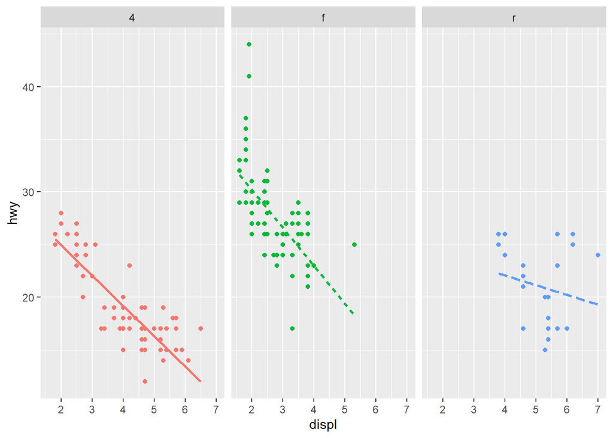

```r
ggplot(data = mpg, mapping = aes(x = displ, y = hwy, color = drv)) +
  geom_point(show.legend = FALSE) +
  geom_smooth(mapping = aes(linetype = drv), method = "lm", se = FALSE, show.legend = FALSE) +
  facet_wrap(vars(drv))
```

Line 1: calls the ggplot function. It gets the data from the data frame (tibble) mpg and assigns displacement to the x-axis, highway miles per gallon to the y axis, and associates color with the vehicle’s drive train.

Line 2: draws a scatterplot. It suppresses the legend that would result because of the color = drv statement.

Lines 3: creates a simple regression line whose color and linetype are determined by the type of drive train. The method = “lm” argument chooses the smoothing method to be simple regression. The se = FALSE clause removes the confidence interval from the graph. The show.legend = FALSE once again prevents a legend from being drawn.

## Write your own code

Draw a scatterplot of linear regressions of city mileage on displacement

1. Put displ on the x-axis
2. Put cty on the y-axis
3. Color the plot symbols by class
4. Draw a simple regression line for each car class without a confidence interval
5. Use facet_wrap to create a graph for each class
6. Suppress the legend

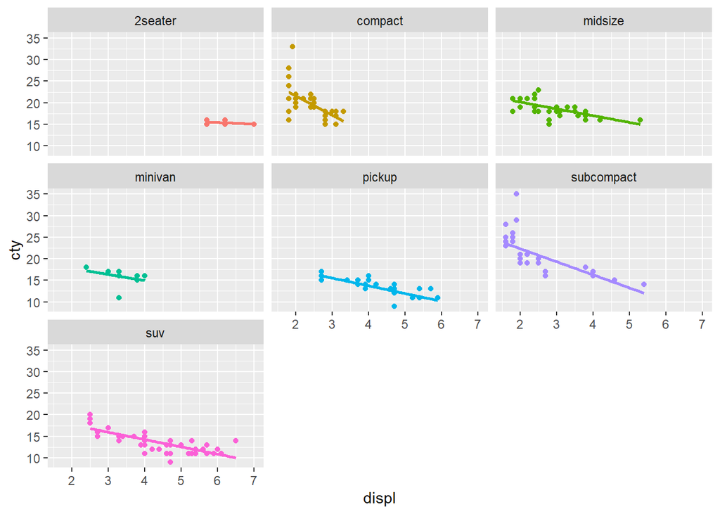

```r
ggplot(data = mpg, mapping = aes(x = displ, y = cty, color = class)) +
  geom_point(show.legend = FALSE) +
  geom_smooth(method = "lm", se = FALSE, show.legend = FALSE) +
  facet_wrap(vars(class))
```